# ny_taxi_sql

## OD matrix estimation for NY taxi data - Mirkó György Mocskonyi (SS0UU2)

```python
import numpy as np
import pandas as pd
import matplotlib.colors as colors
import matplotlib.pyplot as plt
from datetime import datetime

%matplotlib inline
```

Load in the 2013 January taxi trip data.

```python
td1 = pd.read_csv('trip_data_1.csv', index_col=False)
td1.head()
```

|  | medallion | hack_license | vendor_id | rate_code | store_and_fwd_flag | pickup_datetime | dropoff_datetime | passenger_count | trip_time_in_secs | trip_distance | pickup_longitude | pickup_latitude | dropoff_longitude | dropoff_latitude |
| --- | --- | --- | --- | --- | --- | --- | --- | --- | --- | --- | --- | --- | --- | --- |
| 0 | 89D227B655E5C82AECF13C3F540D4CF4 | BA96DE419E711691B9445D6A6307C170 | CMT | 1 | N | 2013-01-01 15:11:48 | 2013-01-01 15:18:10 | 4 | 382 | 1.0 | -73.978165 | 40.757977 | -73.989838 | 40.751171 |
| 1 | 0BD7C8F5BA12B88E0B67BED28BEA73D8 | 9FD8F69F0804BDB5549F40E9DA1BE472 | CMT | 1 | N | 2013-01-06 00:18:35 | 2013-01-06 00:22:54 | 1 | 259 | 1.5 | -74.006683 | 40.731781 | -73.994499 | 40.750660 |
| 2 | 0BD7C8F5BA12B88E0B67BED28BEA73D8 | 9FD8F69F0804BDB5549F40E9DA1BE472 | CMT | 1 | N | 2013-01-05 18:49:41 | 2013-01-05 18:54:23 | 1 | 282 | 1.1 | -74.004707 | 40.737770 | -74.009834 | 40.726002 |
| 3 | DFD2202EE08F7A8DC9A57B02ACB81FE2 | 51EE87E3205C985EF8431D850C786310 | CMT | 1 | N | 2013-01-07 23:54:15 | 2013-01-07 23:58:20 | 2 | 244 | 0.7 | -73.974602 | 40.759945 | -73.984734 | 40.759388 |
| 4 | DFD2202EE08F7A8DC9A57B02ACB81FE2 | 51EE87E3205C985EF8431D850C786310 | CMT | 1 | N | 2013-01-07 23:25:03 | 2013-01-07 23:34:24 | 1 | 560 | 2.1 | -73.976250 | 40.748528 | -74.002586 | 40.747868 |

Drop everything with NaN values and then the columns I am not going to use.

```python
td1 = td1.dropna()
```

```python
td1.drop(['medallion', 'hack_license', 'vendor_id', 'rate_code', 'store_and_fwd_flag', 'passenger_count', 'trip_time_in_secs'], axis = 1, inplace=True)
```

```python
#Take small random portion of the dataset
td1 = td1.sample(frac=0.02, random_state=1).reset_index()
```

```python
idxs = td1.pop("index")
```

Next cell showcases the logic with which I solved the problem. I took the 500 km radius around the center of NY and examined the taxi traffic between concentric circular areas ranging up to 500 km. I converted the lat-lon coordinates to km by using a local flat earth approximation (this disregards the local curvature of Earth and essentially treats the lat-lon coordinates in a local Descartian coordinate system factored with the appropriate coefficients).

```python
earth_radius = 6371

ny_lat = 40.730610
ny_long = -73.935242

unit_long_dist = np.pi/180 * earth_radius * np.cos(ny_lat/180)
unit_lat_dist = 111.2

ny_range = 500

ny_1 = td1[(((td1.pickup_latitude - ny_lat)*unit_lat_dist)**2 + ((td1.pickup_longitude - ny_long)*unit_long_dist)**2 <= ny_range**2) &
    (((td1.dropoff_latitude - ny_lat)*unit_lat_dist)**2 + ((td1.dropoff_longitude - ny_long)*unit_long_dist)**2 <= ny_range**2)]

ny_1["pickup_dist"] = np.sqrt(((td1.pickup_latitude - ny_lat)*unit_lat_dist)**2 + ((td1.pickup_longitude - ny_long)*unit_long_dist)**2)
ny_1["dropoff_dist"] = np.sqrt(((td1.dropoff_latitude - ny_lat)*unit_lat_dist)**2 + ((td1.dropoff_longitude - ny_long)*unit_long_dist)**2)
```

By using the mysql python package I was able to use the MySQL language for the data handling by loading the data into a table created within the MySQL database service of my PC (error shows that I already created the database).

```python
import mysql.connector as mysql
from mysql.connector import Error
try:
    conn = mysql.connect(host='localhost', user='root',
                        password='Anonymus')#give ur username, password
    if conn.is_connected():
        cursor = conn.cursor()
        cursor.execute("CREATE DATABASE taxi")
        print("Database is created")
except Error as e:
    print("Error while connecting to MySQL", e)
```

```
Error while connecting to MySQL 1007 (HY000): Can't create database 'taxi'; database exists
```

Loading the pandas dataframe into a table inside the database.

```python
import mysql.connector as mysql
from mysql.connector import Error
try:
    conn = mysql.connect(host='localhost', database='taxi', user='root', password='Anonymus')
    if conn.is_connected():
        cursor = conn.cursor()
        cursor.execute("select database();")
        record = cursor.fetchone()
        print("You're connected to database: ", record)
        cursor.execute('DROP TABLE IF EXISTS taxi_data;')
        print('Creating table....')
# in the below line please pass the create table statement which you want #to create
        cursor.execute("CREATE TABLE taxi_data(pickup_datetime varchar(255),dropoff_datetime varchar(255),trip_distance FLOAT(0),pickup_longitude FLOAT(0),pickup_latitude FLOAT(0),dropoff_longitude FLOAT(0),dropoff_latitude FLOAT(0))")
        print("Table is created....")
        #loop through the data frame
        for i,row in td1.iterrows():
            #here %S means string values
            sql = "INSERT INTO taxi.taxi_data VALUES (%s,%s,%s,%s,%s,%s,%s)"
            cursor.execute(sql, tuple(row))
            if i % 10000 == 0:
                print("Record inserted: ", i)
            # the connection is not auto committed by default, so we must commit to save our changes
            conn.commit()
except Error as e:
            print("Error while connecting to MySQL", e)
```

```
You're connected to database:  ('taxi',)
Creating table....
Table is created....
Record inserted:  0
Record inserted:  10000
Record inserted:  20000
Record inserted:  30000
Record inserted:  40000
Record inserted:  50000
Record inserted:  60000
Record inserted:  70000
Record inserted:  80000
Record inserted:  90000
Record inserted:  100000
Record inserted:  110000
Record inserted:  120000
Record inserted:  130000
Record inserted:  140000
```

Next I modify the table by introducing the constraints of the concetrical areas around NY up to 500 km radius.

```python
# Execute query
sql_add = "ALTER TABLE taxi.taxi_data ADD COLUMN pickup_dist FLOAT(0), ADD COLUMN dropoff_dist FLOAT(0);"
cursor.execute(sql_add)
sql_cond = "UPDATE taxi.taxi_data SET pickup_dist = POWER(pickup_latitude - 40.73061, 2)*POWER(111.2, 2) + POWER(pickup_longitude + 73.935242, 2)*POWER(108.36029, 2), dropoff_dist = POWER(dropoff_latitude - 40.73061, 2)*POWER(111.2, 2) + POWER(dropoff_longitude + 73.935242, 2)*POWER(108.36029, 2)"
cursor.execute(sql_cond)
sql_sort = "SELECT pickup_dist, dropoff_dist, pickup_datetime, trip_distance FROM taxi.taxi_data WHERE pickup_dist <= 250000 AND dropoff_dist <= 250000 LIMIT 10"
cursor.execute(sql_sort)
# Fetch all the records
result = cursor.fetchall()
"""for i in result:
    print(i)"""
```

```
'for i in result:\n    print(i)'
```

Introducing the borders of the concentrical circular areas.

```python
dist_points = [500, 100, 50, 30, 20, 15, 12, 10, 9, 8, 7, 6, 5, 4, 3, 2, 1, 0]
```

```python
dist_points = dist_points[::-1]
dist_points
```

```
[0, 1, 2, 3, 4, 5, 6, 7, 8, 9, 10, 12, 15, 20, 30, 50, 100, 500]
```

Function to calculate the number of taxi gone from one circular area to another in NY in January 2013:

```python
def get_OD_element(dist_from_idx, dist_to_idx, time_of_day = [6, 11]):
    sql_el = f"SELECT COUNT(pickup_datetime) FROM taxi.taxi_data WHERE (pickup_dist BETWEEN {dist_points[dist_from_idx]} AND {dist_points[dist_from_idx+1]}) AND (dropoff_dist BETWEEN {dist_points[dist_to_idx]} AND {dist_points[dist_to_idx+1]}) AND (HOUR(STR_TO_DATE(pickup_datetime, '%Y-%m-%d %T')) BETWEEN {time_of_day[0]} AND {time_of_day[1]});"
    cursor.execute(sql_el)
    result = cursor.fetchall()
    return result[0][0]
```

And the function to calculate the whole OD matrices for 5 different parts of the day:

```python
def get_OD_matrix(dist_points, times_of_day):
    ODs = []
    for time_of_day in times_of_day:
        OD = []
        for i in range(len(dist_points) - 1):
            OD_x = []
            for j in range(len(dist_points) - 1):
                element = get_OD_element(i, j, time_of_day=time_of_day)
                OD_x.append(element)
            OD.append(OD_x)
        ODs.append(OD)
    return np.array(ODs)
```

Defining the parts of the day to examine:

```python
times_of_day = [[0, 5], [6, 10], [11, 14], [15, 19], [20, 23]]

OD_matrices = get_OD_matrix(dist_points=dist_points, times_of_day=times_of_day)
```

Finally creating a 2dhist heatmap plot for all OD matrices.

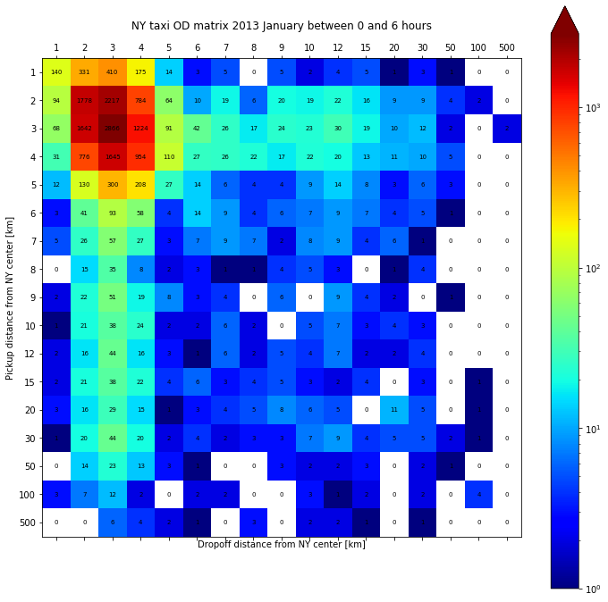

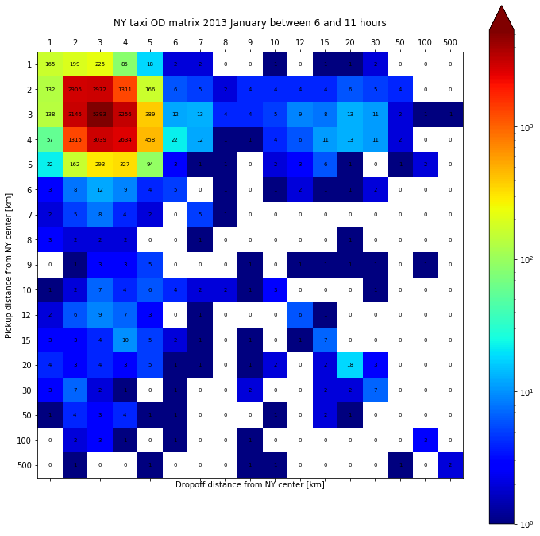

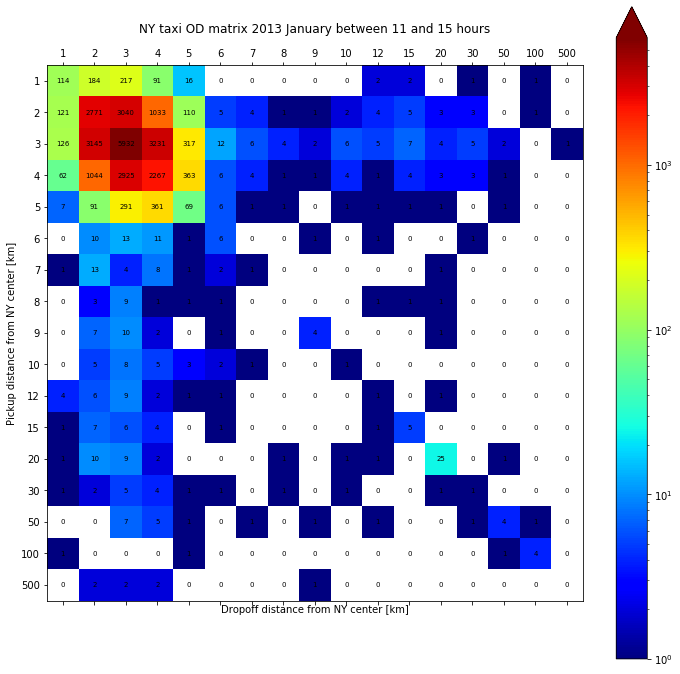

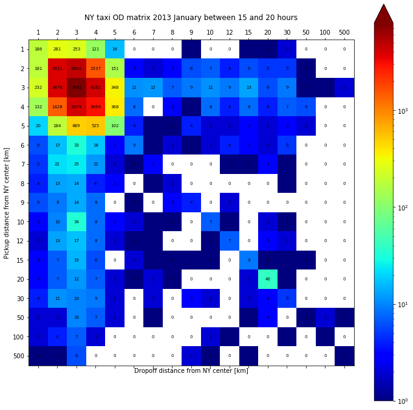

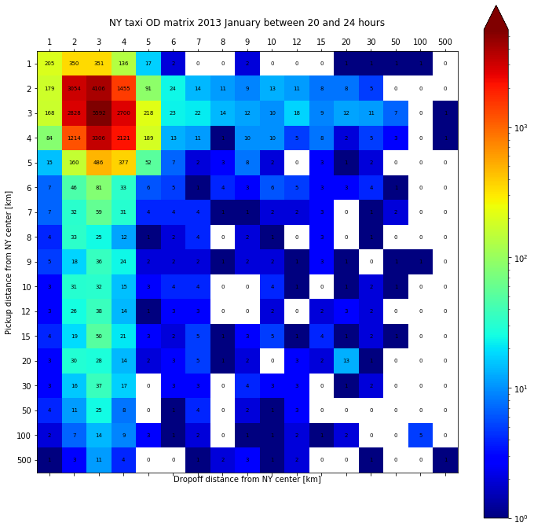

```python
for k in range(OD_matrices.shape[0]):
    fig, ax = plt.subplots(figsize = (12, 12))
    mts = ax.matshow(OD_matrices[k][::-1,::-1].T, norm = colors.LogNorm(vmin = 1, vmax = OD_matrices[k].max()), cmap = plt.cm.jet)
    ax.set_xticks(np.arange(0, len(dist_points)-1))
    ax.set_xticklabels(dist_points[1:])
    ax.set_yticks(np.arange(0, len(dist_points)-1))
    ax.set_yticklabels(dist_points[1:])
    for i in range(len(dist_points)-1):
        for j in range(len(dist_points)-1):
            c = OD_matrices[k][::-1,::-1].T[j,i]
            ax.text(i, j, str(int(c)), va='center', ha='center', fontsize = 7)
    fig.colorbar(mts, ax=ax, extend = 'max')
    ax.set_title(f"NY taxi OD matrix 2013 January between {int(times_of_day[k][0])} and {int(times_of_day[k][1])+1} hours")
    ax.set_xlabel("Dropoff distance from NY center [km]")
    ax.set_ylabel("Pickup distance from NY center [km]")
    plt.savefig(f"od_matrix_{k}.png")
    plt.show()
```